# Analyze_ab_test_results_notebook

## Analyze A/B Test Results

- Introduction
- Part I - Probability
- Part II - A/B Test
- Part III - Regression

### Introduction

For this project, we will be working to understand the results of an A/B test run by an e-commerce website. Our goal is to work through this notebook to help the company understand if they should implement the new page, keep the old page, or perhaps run the experiment longer to make their decision.

#### Part I - Probability

To get started, let's import our libraries.

```python
import pandas as pd
import numpy as np
import random
import matplotlib.pyplot as plt
%matplotlib inline
#We are setting the seed to assure you get the same answers on quizzes as we set up
random.seed(42)
```

`1.` Now, we will read in the `ab_data.csv` data and store it in `df`.

```python
df=pd.read_csv('ab_data.csv')
df.head()
```

|  | user_id | timestamp | group | landing_page | converted |
| --- | --- | --- | --- | --- | --- |
| 0 | 851104 | 2017-01-21 22:11:48.556739 | control | old_page | 0 |
| 1 | 804228 | 2017-01-12 08:01:45.159739 | control | old_page | 0 |
| 2 | 661590 | 2017-01-11 16:55:06.154213 | treatment | new_page | 0 |
| 3 | 853541 | 2017-01-08 18:28:03.143765 | treatment | new_page | 0 |
| 4 | 864975 | 2017-01-21 01:52:26.210827 | control | old_page | 1 |

```python
#The shape of our data

df.shape
```

```
(294478, 5)
```

```python
df.info()
```

```
<class 'pandas.core.frame.DataFrame'>
RangeIndex: 294478 entries, 0 to 294477
Data columns (total 5 columns):
user_id         294478 non-null int64
timestamp       294478 non-null object
group           294478 non-null object
landing_page    294478 non-null object
converted       294478 non-null int64
dtypes: int64(2), object(3)
memory usage: 11.2+ MB
```

```python
df.describe()
```

|  | user_id | converted |
| --- | --- | --- |
| count | 294478.000000 | 294478.000000 |
| mean | 787974.124733 | 0.119659 |
| std | 91210.823776 | 0.324563 |
| min | 630000.000000 | 0.000000 |
| 25% | 709032.250000 | 0.000000 |
| 50% | 787933.500000 | 0.000000 |
| 75% | 866911.750000 | 0.000000 |
| max | 945999.000000 | 1.000000 |

```python
#Finding out unique users by checking unique IDs

df.user_id.nunique()
```

```
290584
```

```python
# duplicated users

df.shape[0]-df.user_id.nunique()
```

```
3894
```

```python
#Proportion of converted users

df.converted.mean()
```

```
0.11965919355605512
```

```python
df.head()
```

|  | user_id | timestamp | group | landing_page | converted |
| --- | --- | --- | --- | --- | --- |
| 0 | 851104 | 2017-01-21 22:11:48.556739 | control | old_page | 0 |
| 1 | 804228 | 2017-01-12 08:01:45.159739 | control | old_page | 0 |
| 2 | 661590 | 2017-01-11 16:55:06.154213 | treatment | new_page | 0 |
| 3 | 853541 | 2017-01-08 18:28:03.143765 | treatment | new_page | 0 |
| 4 | 864975 | 2017-01-21 01:52:26.210827 | control | old_page | 1 |

```python
df.query('landing_page=="new_page" and group=="control"').count()[0]
```

```
1928
```

The number of times the `new_page` and `treatment` don't match.

```python
df.query('(landing_page=="old_page" and group=="treatment")\
or (landing_page=="new_page" and group=="control")').count()[0]
```

```
3893
```

Missing values

```python
df.isna().any(axis=1).sum()
```

```
0
```

`2.` For the rows where **treatment** does not match with **new_page** or **control** does not match with **old_page**, we cannot be sure if this row truly received the new or old page. So we will remove these rows and store our new dataframe in **df2**.

```python
#We will drop those rows as we should only use the rows that we can feel confident in the accuracy of the data.

indices=df.query('(landing_page=="old_page" and group=="treatment")\
or (landing_page=="new_page" and group=="control")').index

df2=df.drop(indices,axis=0)
```

```python
# Double Check all of the correct rows were removed - this should be 0
df2[((df2['group'] == 'treatment') == (df2['landing_page'] == 'new_page')) == False].shape[0]
```

```
0
```

Unique **user_id**s in **df2**

```python
df2.user_id.nunique()
```

```
290584
```

There is one **user_id** repeated in **df2**

```python
df2[df2.user_id.duplicated()].user_id
```

```
2893    773192
Name: user_id, dtype: int64
```

Row information for the repeat **user_id**

```python
df2[df2.user_id.duplicated()]
```

|  | user_id | timestamp | group | landing_page | converted |
| --- | --- | --- | --- | --- | --- |
| 2893 | 773192 | 2017-01-14 02:55:59.590927 | treatment | new_page | 0 |

Remove that row.

```python
df2.drop(2893,axis=0,inplace=True)
```

```python
df2.head()
```

|  | user_id | timestamp | group | landing_page | converted |
| --- | --- | --- | --- | --- | --- |
| 0 | 851104 | 2017-01-21 22:11:48.556739 | control | old_page | 0 |
| 1 | 804228 | 2017-01-12 08:01:45.159739 | control | old_page | 0 |
| 2 | 661590 | 2017-01-11 16:55:06.154213 | treatment | new_page | 0 |
| 3 | 853541 | 2017-01-08 18:28:03.143765 | treatment | new_page | 0 |
| 4 | 864975 | 2017-01-21 01:52:26.210827 | control | old_page | 1 |

The probability of an individual converting regardless of the page they receive:

```python
overall_conversion_rate=df2.converted.mean()

overall_conversion_rate
```

```
0.11959708724499628
```

Given that an individual was in the `control` group, the probability they converted:

```python
control_group=df2.query('group=="control"')

control_converted_mean=control_group.converted.mean()

control_converted_mean
```

```
0.1203863045004612
```

Given that an individual was in the `treatment` group,the probability they converted:

```python
treatment_group=df2.query('group=="treatment"')

treatment_converted_mean=treatment_group.converted.mean()

treatment_converted_mean
```

```
0.11880806551510564
```

The probability that an individual received the new page:

```python
df2.query('landing_page=="new_page"').count()[0]/df2.count()[0]
```

```
0.50006194422266881
```

**Just by examining the probabilities of conversion rates for each group, it is suggested that there is not enough evidence to conclude that the new treatment page leads to more conversions. More specifically, there is about the same amount of people that received the new and old pages, with a probability close to 0.5, while the conversion rates of the `treatment` group (0.1188) are slightly lower than those of the `control` group (0.1203).**

**In other words, for every 100 visits, we will likely have 11.88 ~12 conversions in the treatment group and 12.03 ~12 conversions in the control group.**

### Part II - A/B Test

Notice that because of the time stamp associated with each event, we could technically run a hypothesis test continuously as each observation was observed.

However, then the hard question is do we stop as soon as one page is considered significantly better than another or does it need to happen consistently for a certain amount of time? How long do we run to render a decision that neither page is better than another?

These questions are the difficult parts associated with A/B tests in general.

`1.` For now, we will consider we need to make the decision just based on all the data provided. If we want to assume that the old page is better unless the new page proves to be definitely better at a Type I error rate of 5%, what should our null and alternative hypotheses be?

- **Null Hypothesis** **$H_{0}$** **$=$** **$p_{new}$** **$-$** **$p_{old}$** **$<=$** 0
- **Alternative Hypothesis** **$H_{1}$** **$=$** **$p_{new}$** **$-$** **$p_{old}$** **$>$** 0

`2.` Assume under the null hypothesis, $p_{new}$ and $p_{old}$ both have "true" success rates equal to the **converted** success rate regardless of page - that is $p_{new}$ and $p_{old}$ are equal. Furthermore, assume they are equal to the **converted** rate in **ab_data.csv** regardless of the page.

Use a sample size for each page equal to the ones in **ab_data.csv**.

Perform the sampling distribution for the difference in **converted** between the two pages over 10,000 iterations of calculating an estimate from the null.

What is the **conversion rate** for $p_{new}$ under the null?

**We assumed that under the null hypothesis: *$p_{new} = p_{old}=0.11959$* that is the overall conversion rate, regardless of page that we found previously.**

So, *$p_{new} = 0.1195$*

```python
p_new=overall_conversion_rate
p_new
```

```
0.11959708724499628
```

What is the **conversion rate** for $p_{old}$ under the null?

We assumed that under the null hypothesis: *$p_{new} = p_{old}=0.11959$* that is the overall conversion rate, regardless of page that we found previously.

So, *$p_{old} = 0.1195$*

```python
p_old=overall_conversion_rate
p_old
```

```
0.11959708724499628
```

What is $n_{new}$, the number of individuals in the treatment group?

```python
n_new=df2.query('landing_page=="new_page"').count()[0]
n_new
```

```
145310
```

What is $n_{old}$, the number of individuals in the control group?

```python
n_old=df2.query('landing_page=="old_page"').count()[0]
n_old
```

```
145274
```

Simulate $n_{new}$ transactions with a conversion rate of $p_{new}$ under the null. Store these $n_{new}$ 1's and 0's in **new_page_converted**.

```python
new_page_converted=np.random.choice([0,1],n_new,p=[1-p_new,p_new])
```

Simulate $n_{old}$ transactions with a conversion rate of $p_{old}$ under the null. Store these $n_{old}$ 1's and 0's in **old_page_converted**.

```python
old_page_converted=np.random.choice([0,1],n_old,p=[1-p_old,p_old])
```

Find $p_{new}$ - $p_{old}$ for your simulated values from part (e) and (f).

```python
p_new=new_page_converted.mean()
p_old=old_page_converted.mean()

diff=p_new-p_old
diff
```

```
0.0007891681431484443
```

Create 10,000 $p_{new}$ - $p_{old}$ values using the same simulation process we used earlier above. Store all 10,000 values in a NumPy array called **p_diffs**.

```python
p_diffs=[]
for i in range(10000):
    new_page_converted=np.random.choice([0,1],n_new,p=[1-p_new,p_new])
    old_page_converted=np.random.choice([0,1],n_old,p=[1-p_old,p_old])
    p_diffs.append(new_page_converted.mean() - old_page_converted.mean())
```

```python
p_diffs=np.array(p_diffs)
```

```python
#The sample mean

p_diffs.mean()
```

```
0.00079949918896633635
```

We plot a histogram of the **p_diffs**.

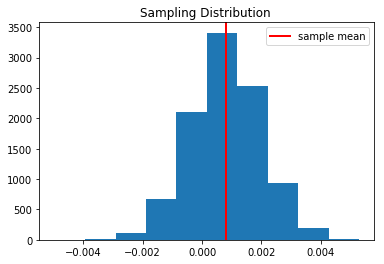

```python
plt.hist(p_diffs)
plt.axvline(p_diffs.mean(),color='r',linewidth=2,label='sample mean')
plt.title('Sampling Distribution ')
plt.legend();
```

What proportion of the **p_diffs** are greater than the actual difference observed in **ab_data.csv**?

```python
#Observed actual difference

obs_diff=treatment_converted_mean - control_converted_mean
obs_diff
```

```
-0.0015782389853555567
```

```python
p_diffs.mean(), obs_diff
```

```
(0.00079949918896633635, -0.0015782389853555567)
```

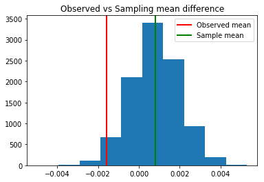

```python
plt.hist(p_diffs)
plt.axvline(obs_diff,color='r',linewidth=2,label='Observed mean')
plt.axvline(p_diffs.mean(),color='g',linewidth=2,label='Sample mean')
plt.title('Observed vs Sampling mean difference')
plt.legend();
```

```python
#calculating p-value
(p_diffs>obs_diff).mean()
```

```
0.97570000000000001
```

**We calculated the percentage of observations from the sampling distribution that are above the actual, observed mean difference in our dataset. This is the p-value, and tells us the probability of seeing this sample mean or any other extreme to the alternative hypothesis when *$H_{0}$* is true.**

**Since the p-value is extremely high and higher than our Type I error rate threshold $a=0.05<0.975$ then we conclude that our observed statistic, *$p_{new} - p_{old} = -0.001578$* comes from the null hypothesis that *$p_{new} - p_{old} <=0$*. So, we cant reject the null.** **Practically, this result tells us that there should not be a change to the website of the company as there's no benefit to it**

We could also use a built-in to achieve similar results. Though using the built-in might be easier to code, the above portions are a walkthrough of the ideas that are critical to correctly thinking about statistical significance.

```python
import statsmodels.api as sm

convert_old = df2.query('group=="control"').converted.sum()
convert_new = df2.query('group=="treatment"').converted.sum()
n_old = df2.query('landing_page=="old_page"').count()[0]
n_new = df2.query('landing_page=="new_page"').count()[0]
```

Now we will use `stats.proportions_ztest` to compute our test statistic and p-value.

```python
stat,pval = sm.stats.proportions_ztest(count=[convert_old,convert_new],nobs=[n_old,n_new],alternative='smaller')
```

```python
stat, pval
```

```
(1.3109241984234394, 0.90505831275902449)
```

**The z score tells us how many standard deviations below or above the population mean our point is. Here we are 1.31 standard deviations above the mean as the score is positive. In addition, we have a very high p-value, similar to our previous results, which suggests that our result likely comes from the null hypothesis and we fail to reject it.**

### Part III - A regression approach

`1.` In this final part, we will see that the result we achieved in the A/B test in Part II above can also be achieved by performing regression.

Since each row is either a conversion or no conversion, we need to perform a logistic regression as we care to predict a response with two categorical outcomes.

The goal is to use **statsmodels** to fit the regression model we specified earlier to see if there is a significant difference in conversion based on which page a customer receives. However, we first need to create in df2 a column for the intercept, and create a dummy variable column for which page each user received. We will add an **intercept** column, as well as an **ab_page** column, which is 1 when an individual receives the **treatment** and 0 if **control**.

```python
df2.head()
```

|  | user_id | timestamp | group | landing_page | converted |
| --- | --- | --- | --- | --- | --- |
| 0 | 851104 | 2017-01-21 22:11:48.556739 | control | old_page | 0 |
| 1 | 804228 | 2017-01-12 08:01:45.159739 | control | old_page | 0 |
| 2 | 661590 | 2017-01-11 16:55:06.154213 | treatment | new_page | 0 |
| 3 | 853541 | 2017-01-08 18:28:03.143765 | treatment | new_page | 0 |
| 4 | 864975 | 2017-01-21 01:52:26.210827 | control | old_page | 1 |

```python
df2['intercept']=1

df2[['old_page','new_page']]=pd.get_dummies(df2['landing_page'])
df2[['control','ab_page']]=pd.get_dummies(df2['group'])
```

```python
df2.drop('control',axis=1,inplace=True)
```

```python
df2.head()
```

|  | user_id | timestamp | group | landing_page | converted | intercept | old_page | new_page | ab_page |
| --- | --- | --- | --- | --- | --- | --- | --- | --- | --- |
| 0 | 851104 | 2017-01-21 22:11:48.556739 | control | old_page | 0 | 1 | 0 | 1 | 0 |
| 1 | 804228 | 2017-01-12 08:01:45.159739 | control | old_page | 0 | 1 | 0 | 1 | 0 |
| 2 | 661590 | 2017-01-11 16:55:06.154213 | treatment | new_page | 0 | 1 | 1 | 0 | 1 |
| 3 | 853541 | 2017-01-08 18:28:03.143765 | treatment | new_page | 0 | 1 | 1 | 0 | 1 |
| 4 | 864975 | 2017-01-21 01:52:26.210827 | control | old_page | 1 | 1 | 0 | 1 | 0 |

We will use **statsmodels** to instantiate our regression model on the two columns we created above. Then fit the model to predict whether or not an individual converts.

```python
lm=sm.Logit(df2['converted'],df2[['intercept','ab_page']])
results=lm.fit()
```

```
Optimization terminated successfully.
         Current function value: 0.366118
         Iterations 6
```

### Summary

```python
results.summary2()
```

| Model: | Logit | No. Iterations: | 6.0000 |
| --- | --- | --- | --- |
| Dependent Variable: | converted | Pseudo R-squared: | 0.000 |
| Date: | 2021-08-18 17:47 | AIC: | 212780.3502 |
| No. Observations: | 290584 | BIC: | 212801.5095 |
| Df Model: | 1 | Log-Likelihood: | -1.0639e+05 |
| Df Residuals: | 290582 | LL-Null: | -1.0639e+05 |
| Converged: | 1.0000 | Scale: | 1.0000 |

|  | Coef. | Std.Err. | z | P>\|z\| | [0.025 | 0.975] |
| --- | --- | --- | --- | --- | --- | --- |
| intercept | -1.9888 | 0.0081 | -246.6690 | 0.0000 | -2.0046 | -1.9730 |
| ab_page | -0.0150 | 0.0114 | -1.3109 | 0.1899 | -0.0374 | 0.0074 |

What is the p-value associated with **ab_page**? Why does it differ from the value you found in **Part II**?

**The p-value asssociated with ab_page is 0.1899. It is the p-value for the null Hypothesis that the inercept of ab_page is zero. In other words, that ab_page does not explain the response, that is the conversion. Since our p-value is quite high and higher than the threshold $a=0.05$ then we conclude that we can't reject the null and therefore the ab_page is not statistically significant in explaining the conversion.**

**In part II, we examined the hypothesis $H_{0}: p_{new}-p_{old}<=0$ which was an one side check. However, now we check whether the slope of ab_page equals to zero. In both tests we come to the same conclusion, that being in the `treatment` group or in other words receiving the `new_page` does not affect the conversion rate positively.**

**Considering more factors to add into our regression could be helpful in order to explain the response in a more complete way and in case we have ignored important factors that could make a significant difference.**

**However, a potential disadvantage of adding additional terms to our model is multi-collinearity. Which means that the x-variables could be correlated with one another. We would like the explanatory variables to be correlated with the response but not with one another as that could lead to unexpected and unreliable relations between the x-variables and the response. The presence of multi-collinearity could also make our coefficient estimates less stable due to high standard errors.**

Now along with testing if the conversion rate changes for different pages,we will also add an effect based on which country a user lives in. We will need to read in the **countries.csv** dataset and merge together our datasets on the appropriate rows.

```python
countries=pd.read_csv('countries.csv')
countries.head()
```

|  | user_id | country |
| --- | --- | --- |
| 0 | 834778 | UK |
| 1 | 928468 | US |
| 2 | 822059 | UK |
| 3 | 711597 | UK |
| 4 | 710616 | UK |

```python
df2=df2.join(countries.set_index('user_id'),on='user_id')
```

```python
df2.head()
```

|  | user_id | timestamp | group | landing_page | converted | intercept | old_page | new_page | ab_page | country |
| --- | --- | --- | --- | --- | --- | --- | --- | --- | --- | --- |
| 0 | 851104 | 2017-01-21 22:11:48.556739 | control | old_page | 0 | 1 | 0 | 1 | 0 | US |
| 1 | 804228 | 2017-01-12 08:01:45.159739 | control | old_page | 0 | 1 | 0 | 1 | 0 | US |
| 2 | 661590 | 2017-01-11 16:55:06.154213 | treatment | new_page | 0 | 1 | 1 | 0 | 1 | US |
| 3 | 853541 | 2017-01-08 18:28:03.143765 | treatment | new_page | 0 | 1 | 1 | 0 | 1 | US |
| 4 | 864975 | 2017-01-21 01:52:26.210827 | control | old_page | 1 | 1 | 0 | 1 | 0 | US |

```python
df2[['CA','UK','US']]=pd.get_dummies(df2['country'])
```

```python
df2.head()
```

|  | user_id | timestamp | group | landing_page | converted | intercept | old_page | new_page | ab_page | country | CA | UK | US |
| --- | --- | --- | --- | --- | --- | --- | --- | --- | --- | --- | --- | --- | --- |
| 0 | 851104 | 2017-01-21 22:11:48.556739 | control | old_page | 0 | 1 | 0 | 1 | 0 | US | 0 | 0 | 1 |
| 1 | 804228 | 2017-01-12 08:01:45.159739 | control | old_page | 0 | 1 | 0 | 1 | 0 | US | 0 | 0 | 1 |
| 2 | 661590 | 2017-01-11 16:55:06.154213 | treatment | new_page | 0 | 1 | 1 | 0 | 1 | US | 0 | 0 | 1 |
| 3 | 853541 | 2017-01-08 18:28:03.143765 | treatment | new_page | 0 | 1 | 1 | 0 | 1 | US | 0 | 0 | 1 |
| 4 | 864975 | 2017-01-21 01:52:26.210827 | control | old_page | 1 | 1 | 0 | 1 | 0 | US | 0 | 0 | 1 |

```python
lm=sm.Logit(df2['converted'],df2[['intercept','ab_page','UK','CA']])
results=lm.fit()
results.summary2()
```

```
Optimization terminated successfully.
         Current function value: 0.366113
         Iterations 6
```

| Model: | Logit | No. Iterations: | 6.0000 |
| --- | --- | --- | --- |
| Dependent Variable: | converted | Pseudo R-squared: | 0.000 |
| Date: | 2021-08-18 17:53 | AIC: | 212781.1253 |
| No. Observations: | 290584 | BIC: | 212823.4439 |
| Df Model: | 3 | Log-Likelihood: | -1.0639e+05 |
| Df Residuals: | 290580 | LL-Null: | -1.0639e+05 |
| Converged: | 1.0000 | Scale: | 1.0000 |

|  | Coef. | Std.Err. | z | P>\|z\| | [0.025 | 0.975] |
| --- | --- | --- | --- | --- | --- | --- |
| intercept | -1.9893 | 0.0089 | -223.7628 | 0.0000 | -2.0067 | -1.9718 |
| ab_page | -0.0149 | 0.0114 | -1.3069 | 0.1912 | -0.0374 | 0.0075 |
| UK | 0.0099 | 0.0133 | 0.7433 | 0.4573 | -0.0162 | 0.0359 |
| CA | -0.0408 | 0.0269 | -1.5161 | 0.1295 | -0.0934 | 0.0119 |

```python
#Interpreting coefficients

print("UK coefficient:",np.exp(0.0099))
print("CA coefficient:",1/np.exp(-0.0408))
```

```
UK coefficient: 1.00994916712
CA coefficient: 1.04164375596
```

### Conclusions

Though we have now looked at the individual factors of country and page on conversion, we would now like to look at an interaction between page and country to see if there significant effects on conversion.

```python
df2.head()
```

|  | user_id | timestamp | group | landing_page | converted | intercept | old_page | new_page | ab_page | country | CA | UK | US |
| --- | --- | --- | --- | --- | --- | --- | --- | --- | --- | --- | --- | --- | --- |
| 0 | 851104 | 2017-01-21 22:11:48.556739 | control | old_page | 0 | 1 | 0 | 1 | 0 | US | 0 | 0 | 1 |
| 1 | 804228 | 2017-01-12 08:01:45.159739 | control | old_page | 0 | 1 | 0 | 1 | 0 | US | 0 | 0 | 1 |
| 2 | 661590 | 2017-01-11 16:55:06.154213 | treatment | new_page | 0 | 1 | 1 | 0 | 1 | US | 0 | 0 | 1 |
| 3 | 853541 | 2017-01-08 18:28:03.143765 | treatment | new_page | 0 | 1 | 1 | 0 | 1 | US | 0 | 0 | 1 |
| 4 | 864975 | 2017-01-21 01:52:26.210827 | control | old_page | 1 | 1 | 0 | 1 | 0 | US | 0 | 0 | 1 |

```python
df2['page_UK']=df2['ab_page']*df2['UK']
df2['page_CA']=df2['ab_page']*df2['CA']
df2['page_US']=df2['ab_page']*df2['US']

df2.head()
```

|  | user_id | timestamp | group | landing_page | converted | intercept | old_page | new_page | ab_page | country | CA | UK | US | page_UK | page_CA | page_US |
| --- | --- | --- | --- | --- | --- | --- | --- | --- | --- | --- | --- | --- | --- | --- | --- | --- |
| 0 | 851104 | 2017-01-21 22:11:48.556739 | control | old_page | 0 | 1 | 0 | 1 | 0 | US | 0 | 0 | 1 | 0 | 0 | 0 |
| 1 | 804228 | 2017-01-12 08:01:45.159739 | control | old_page | 0 | 1 | 0 | 1 | 0 | US | 0 | 0 | 1 | 0 | 0 | 0 |
| 2 | 661590 | 2017-01-11 16:55:06.154213 | treatment | new_page | 0 | 1 | 1 | 0 | 1 | US | 0 | 0 | 1 | 0 | 0 | 1 |
| 3 | 853541 | 2017-01-08 18:28:03.143765 | treatment | new_page | 0 | 1 | 1 | 0 | 1 | US | 0 | 0 | 1 | 0 | 0 | 1 |
| 4 | 864975 | 2017-01-21 01:52:26.210827 | control | old_page | 1 | 1 | 0 | 1 | 0 | US | 0 | 0 | 1 | 0 | 0 | 0 |

```python
lm=sm.Logit(df2['converted'],df2[['intercept','ab_page','CA','UK','page_CA','page_UK']])
results=lm.fit()
results.summary2()
```

```
Optimization terminated successfully.
         Current function value: 0.366109
         Iterations 6
```

| Model: | Logit | No. Iterations: | 6.0000 |
| --- | --- | --- | --- |
| Dependent Variable: | converted | Pseudo R-squared: | 0.000 |
| Date: | 2021-08-18 17:54 | AIC: | 212782.6602 |
| No. Observations: | 290584 | BIC: | 212846.1381 |
| Df Model: | 5 | Log-Likelihood: | -1.0639e+05 |
| Df Residuals: | 290578 | LL-Null: | -1.0639e+05 |
| Converged: | 1.0000 | Scale: | 1.0000 |

|  | Coef. | Std.Err. | z | P>\|z\| | [0.025 | 0.975] |
| --- | --- | --- | --- | --- | --- | --- |
| intercept | -1.9865 | 0.0096 | -206.3440 | 0.0000 | -2.0053 | -1.9676 |
| ab_page | -0.0206 | 0.0137 | -1.5052 | 0.1323 | -0.0473 | 0.0062 |
| CA | -0.0175 | 0.0377 | -0.4652 | 0.6418 | -0.0914 | 0.0563 |
| UK | -0.0057 | 0.0188 | -0.3057 | 0.7598 | -0.0426 | 0.0311 |
| page_CA | -0.0469 | 0.0538 | -0.8718 | 0.3833 | -0.1523 | 0.0585 |
| page_UK | 0.0314 | 0.0266 | 1.1807 | 0.2377 | -0.0207 | 0.0835 |

```python
#coefficients

print('UK:',1/np.exp(-0.0188))
print('CA:',1/np.exp(-0.0175))
print('page_CA',1/np.exp(-0.0469))
print('page_UK',1/np.exp(-0.0314))
```

[output not shown]

### Conclusions

**All the coefficients are very close to 1 compared to the baselines US and page_US. In addition our p-values are all very high and above 0.05 so none of those results are statistically significant and do not explain the response. There is no statistical or practical reasoning for the e-commerce website to change its old page for a new one**